# Manhattan: ggplot2-based Manhattan plots

Boxiang Liu

2017-12-15

The Manhattan plot is a specialized form of scatterplot to display genome-wide association studies (GWAS). The x-axis of a Manhattan plot is the genomic position, and the y-axis is usually the $-log_{10}(P\text{-}value)$ (although other sensible metric can be used as well).

There are many packages for making Manhattan plots, but most of them are not easily extensible. The package `ggplot2` has become increasingly popular among the $\textbf{R}$ and bioinformatics communities. Therefore, a package that is fully compatible with `ggplot2` and customizable with its `geom`s will facilitate the use of Manhattan plots.

Introducing `manhattan`, a `ggplot2` based package for making Manhattan plots. It takes in a `data.frame` and returns a standard `ggplot` object, upon which the user can add other `geom`s. This makes it very convenient for users to build on `manhattan` and customize their plots.

## Installation

To install `manhattan`, use the standard R package installation command.

```r
# install.packages('manhattan')
```

If you want the latest development version, install it using `devtools`.

```r
devtools::install_github("boxiangliu/manhattan")
```

The package has been tested on Linux and Mac OSX. It has not been tested on Windows.

## Usage

### Basic Manhattan plot

To illustate its usage, let us plot the coronary artery disease GWAS based on *Deloukas et al*(2013). The original dataset provides nominal p-values. Since we want to plot the $-log_{10}(P\text{-}value)$, let us take the logarithm.

```r
library(manhattan)
data(cad_gwas)
cad_gwas$y=-log10(cad_gwas$pval)
head(cad_gwas)
```

```
##    chrom       pos     pval       rsid         y
## 1:  chr1 100098846 0.180432   rs494626 0.7436864
## 2:  chr1 100128148 0.030573 rs10747505 1.5146619
## 3:  chr1 100183875 0.081842  rs1541044 1.0870238
## 4:  chr1 100258576 0.423634   rs531174 0.3730092
## 5:  chr1 100351915 0.518362  rs2810422 0.2853668
## 6:  chr1 100385263 0.190763   rs499479 0.7195059
```

The dataset contains five columns: `chrom`, `pos`, `rsid`, `pval`, and `y`. Three of them are required:

1. `chrom`
2. `pos`
3. `y`

The `chrom` and `pos` columns specify the genomic location (x-axis), and `y` specify the y-axis (duh!). The choice of the column name “y” is intentional - not every Manhanttan plot uses $-log_{10}{P\text{-}value}$ as the y-axis. After loading the data, we are ready to make a Manhattan plot. Notice that *Deloukas et al* uses hg18. To get the chromosome lengths correctly, we specify hg18 as an argument.

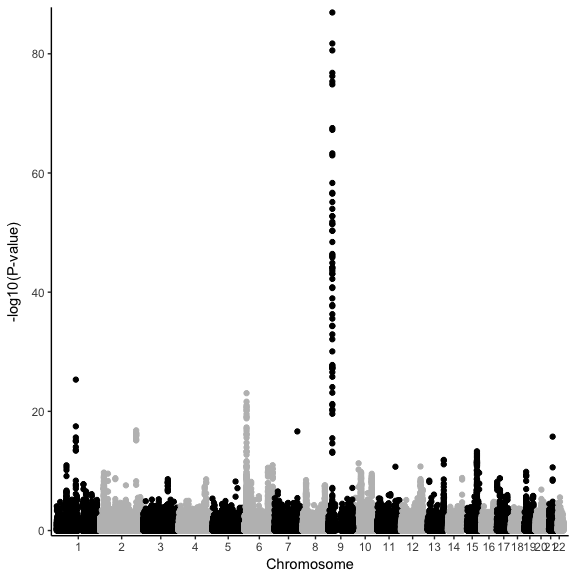

```r
manhattan(cad_gwas,build='hg18')
```

Ta-da! Our first Manhattan plot.

### Customizing colors

If black and grey are dull, we can change the color of each chromosome.

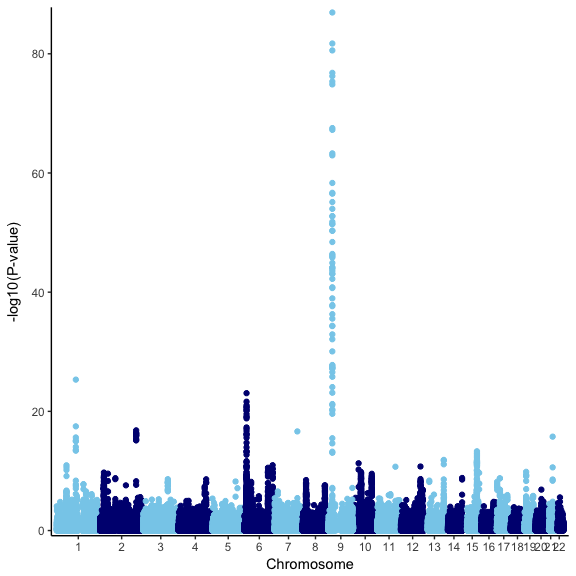

```r
manhattan(cad_gwas,build='hg18',color1='skyblue',color2='navyblue')
```

### Highlight and label SNPs and genes

A common task is to highlight and annotate SNPs of interest. The package `manhattan` requires color and SNP labels to be specified in the input `data.frame` as two columns: color and label. Note that only SNPs of interest have color strings, and other SNPs **must be left as `NA`**.

Let us highlight two SNPs rs602633 and rs1333045.

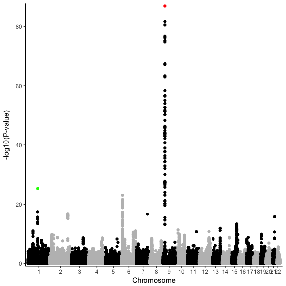

```r
cad_gwas[cad_gwas$rsid=='rs602633','color']='green'
cad_gwas[cad_gwas$rsid=='rs1333045','color']='red'
manhattan(cad_gwas,build='hg18')
```

We could also label the two SNPs. Note again that only SNPs of interest have label strings, other SNPs should be left as `NA`s. Since manhattan returns a `ggpplot` object, we could just add a `geom_text` layer.

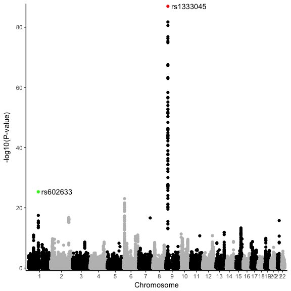

```r
cad_gwas[cad_gwas$rsid=='rs602633','label']='rs602633'
cad_gwas[cad_gwas$rsid=='rs1333045','label']='rs1333045'
manhattan(cad_gwas,build='hg18')+geom_text(aes(label=label),hjust=-0.1)
```

### Adding GWAS significance line

It is worth noting that any standard `geom`s can be used with `manhattan`. For instance, let’s add a line indicating genome-wide significant threshold.

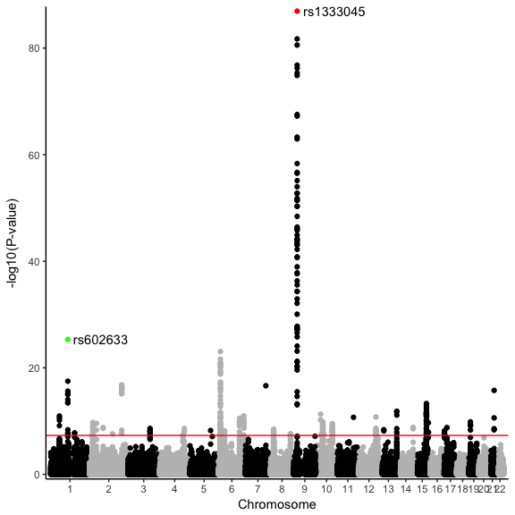

```r
manhattan(cad_gwas,build='hg18')+geom_text(aes(label=label),hjust=-0.1)+geom_hline(yintercept=-log10(5e-8),color='red')
```

### Plotting multiple GWAS studies

We can go even further to use facets with `manhattan`. For illustration, let us pretend that we have two GWAS studies by duplicating `cad_gwas`, and plot two GWAS studies on top of each other.

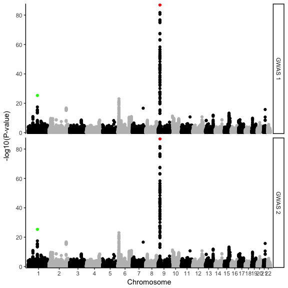

```r
cad_gwas_2=rbind(cbind(cad_gwas,study='GWAS 1'),cbind(cad_gwas,study='GWAS 2'))
manhattan(cad_gwas_2,build='hg18')+facet_grid(study~.)
```

## Details

Behind the scene, `manhattan` is no more than a wrapper around `ggplot`, with a few tricks to transform a genomic axis to a scatterplot axis. In brief, `manhattan` transforms the chrom:pos pairs to cumulative positions. For instance, chr2:1 would be the length of chromosome 1 plus 1, chr3:1 would be chromosome 1 plus chromosome 2 plus 1, so on and so forth. Therefore, it is important to specify the genomic build (e.g. hg19) so that `manhattan` can make the correct transformation. It then positions the chromosome labels on the x-axis according to these transformations.

Again, it is important to note that `manhattan` is no more than a wrapper around `ggplot`, which makes `manhattan` highly customizable. For instance, we can change the size of the SNPs of interest by adding a `geom_point` layer.

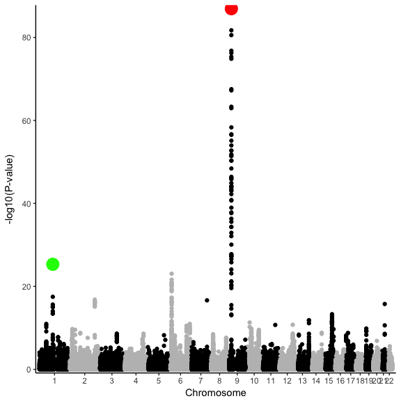

```r
cad_gwas$size=ifelse(cad_gwas$rsid%in%c('rs602633','rs1333045'),5,2)
manhattan(cad_gwas,build='hg18')+geom_point(aes(color=color,size=size),show.legend=FALSE)
```

## Questions and Bugs

If you have any question or want to report a bug, please open a github issue [here](https://github.com/boxiangliu/manhattan/issues).